[Edit on GitHub](https://github.com/DanielVandH/DelaunayTriangulation.jl/tree/main/docs/src/literate_tutorials/unconstrained.jl)

# Unconstrained Triangulations

Our first example considers constructing unconstrained Delaunay triangulations. To start, let us load in the packages we will need.

```julia
using DelaunayTriangulation
using CairoMakie # for plotting
using StableRNGs # for reproducibility
using LinearAlgebra # used for computing norms later
```

We consider just triangulating a random set of points. First, generating the points:

```julia
rng = StableRNG(123)
points = rand(rng, 2, 500) # just do rand(2, 500) if you are not concerned about the RNG
```

```
2×500 Matrix{Float64}:
 0.181026  0.669058   0.437991  0.763974  …  0.459817   0.312727  0.0634304
 0.36749   0.0427306  0.48329   0.924483     0.0794176  0.892313  0.606559
```

We now triangulate these points by using `triangulate`. We pass the `rng` as a keyword argument, but again if you are not concerned about the RNG (or set the seed using `Random.seed!`) then you can ignore this.

```julia
tri = triangulate(points; rng=rng)
```

```
Delaunay Triangulation.
    Constrained: false
    Has ghost triangles: false
    Number of points: 500
    Number of triangles: 980
    Number of edges: 1497
```

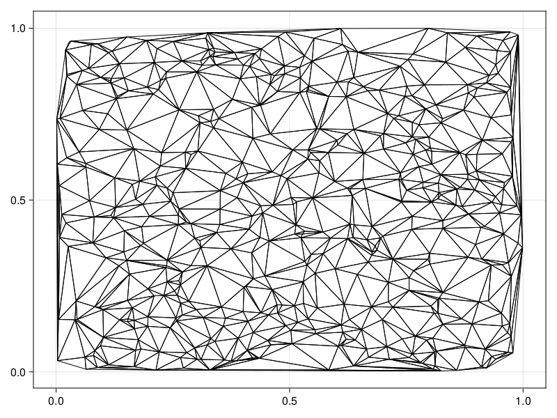

```julia
fig, ax, sc = triplot(tri)
fig
```

## Iterating over vertices

For example, we can iterate over the points in the triangulation using `each_solid_vertex`. Here we compute the centroid of the point cloud:

```julia
function compute_centroid(tri)
    s = [0.0, 0.0]
    for i in each_solid_vertex(tri)
        p = get_point(tri, i)
        s .+= p
    end
    s ./= num_solid_vertices(tri)
    return s
end
s = compute_centroid(tri)
```

```
2-element Vector{Float64}:
 0.5106629621450197
 0.477077379328767
```

We need to use the `solid` identifier because triangulations are made up of both *solid* and *ghost* vertices/edges/triangles, for reasons described in the manual. If we just use `each_vertex(tri)`, then we also find a vertex `-1` that corresponds to the boundary. For example, the points on the boundary can be obtained using:

```julia
get_neighbours(tri, -1)
```

```
Set{Int64} with 18 elements:
  176
  456
  425
  258
  325
  398
  197
  219
  319
  262
  112
  345
  371
  232
  245
  163
  468
  140
```

One reason to be careful with this especially is that `get_point(tri, -1)` does actually correspond to a coordinate,

```julia
get_point(tri, -1)
```

```
(0.500547641525688, 0.497711096515429)
```

(This is the pole of inaccessibility for the domain; see here for more details.) You can use `each_vertex` or `each_ghost_vertex` to consider all types of vertices or only the ghost vertices. If you just want the vertices, use `get_vertices(tri)`, which will also include the boundary vertex.

```julia
get_vertices(tri)
```

```
Set{Int64} with 501 elements:
  56
  35
  429
  425
  60
  220
  308
  67
  215
  73
  319
  251
  115
  112
  348
  185
  420
  404
  417
  ⋮
```

## Iterating over edges

We can also iterate over the edges of the triangulation using `each_solid_edge`, or `each_edge` for both solid and ghost edges and `each_ghost_edge` for only the ghost edges. To give an example, here we compute the average length of an edge.

```julia
function compute_mean_edge_length(tri)
    ℓ = 0.0
    for e in each_solid_edge(tri)
        u, v = edge_indices(e)
        p, q = get_point(tri, u, v)
        ℓ += norm(p .- q)
    end
    ℓ /= num_solid_edges(tri)
    return ℓ
end
ℓ = compute_mean_edge_length(tri)
```

```
0.056456938080335355
```

By default, the triangulation has no ghost edges, so `each_edge` and `each_solid_edge` are the same. You can also use the accessor `get_edges` to get all the edges, including the ghost edges if there were any.

```julia
get_edges(tri)
```

```
Set{Tuple{Int64, Int64}} with 1497 elements:
  (276, 329)
  (50, 458)
  (4, 197)
  (58, 438)
  (106, 299)
  (34, 313)
  (345, 446)
  (412, 433)
  (261, 271)
  (292, 304)
  (115, 379)
  (274, 334)
  (212, 464)
  (435, 472)
  (124, 320)
  (86, 379)
  (63, 413)
  (94, 132)
  (96, 104)
  ⋮
```

Note also that the edges are all given as unordered, so the set of edges only includes one of `(i, j)` and `(j, i)` for each edge `(i, j)`.

## Iterating over triangles

Similarly, we can iterate over the triangles using `each_triangle`, `each_ghost_triangle`, or `each_triangle`. By default, ghost triangles are not included in the output. Here we compute the area of the domain by getting the area of each triangle.

```julia
area(p, q, r) = 0.5 * ((getx(q) - getx(p)) * (gety(r) - gety(p)) - (gety(q) - gety(p)) * (getx(r) - getx(p)))
function compute_triangulation_area(tri)
    A = 0.0
    for T in each_solid_triangle(tri)
        i, j, k = indices(T)
        p, q, r = get_point(tri, i, j, k)
        A += area(p, q, r)
    end
    return A
end
A = compute_triangulation_area(tri)
```

```
0.9683345161527975
```

(You can compute areas like this using `get_total_area(tri)`.) You can access the set of `triangles` using `get_triangles(tri)`:

```julia
get_triangles(tri)
```

```
Set{Tuple{Int64, Int64, Int64}} with 980 elements:
  (163, 365, 295)
  (383, 473, 297)
  (499, 260, 216)
  (239, 43, 274)
  (461, 7, 430)
  (230, 257, 316)
  (57, 203, 80)
  (277, 284, 233)
  (74, 144, 474)
  (361, 368, 111)
  (450, 77, 207)
  (220, 327, 315)
  (151, 329, 276)
  (196, 401, 362)
  (255, 294, 97)
  (35, 121, 364)
  (452, 303, 371)
  (296, 499, 105)
  (150, 330, 469)
  ⋮
```

The triangles are all positively oriented, meaning the triangles are given such that the corresponding points are traversed in counter-clockwise order.

## Querying neighbour information

We can query neighbour information at several levels.

### Points

For a given point, there are two type of neighbours: The neighbouring vertices, and the neighbouring triangles. The neighbours can be obtained using `get_neighbours`. For example, the set of vertices that share an edge with the fifth vertex is:

```julia
get_neighbours(tri, 5)
```

```
Set{Int64} with 4 elements:
  93
  117
  301
  214
```

The set of triangles that share an edge with the fifth vertex is obtained using `get_adjacent2vertex`. This returns a set of edges `(v, w)` such that, for a given vertex `u`, `(u, v, w)` is a positively oriented triangle in the triangulation. For example,

```julia
get_adjacent2vertex(tri, 5)
```

```
Set{Tuple{Int64, Int64}} with 4 elements:
  (93, 117)
  (117, 301)
  (301, 214)
  (214, 93)
```

means that the triangles that contain `5` as a vertex are `(5, 93, 117)`, `(5, 117, 301)`, `(5, 301, 214)`, and `(5, 214, 93)`. We can verify this:

```julia
filter(T -> 5 ∈ indices(T), get_triangles(tri))
```

```
Set{Tuple{Int64, Int64, Int64}} with 4 elements:
  (93, 5, 214)
  (301, 5, 117)
  (93, 117, 5)
  (301, 214, 5)
```

These queries can also be applied to the ghost vertices, in which information about the boundary is provided.

```julia
get_neighbours(tri, -1)
```

```
Set{Int64} with 18 elements:
  176
  456
  425
  258
  325
  398
  197
  219
  319
  262
  112
  345
  371
  232
  245
  163
  468
  140
```

```julia
get_adjacent2vertex(tri, -1)
```

```
Set{Tuple{Int64, Int64}} with 18 elements:
  (468, 232)
  (398, 258)
  (176, 371)
  (425, 456)
  (232, 163)
  (112, 262)
  (258, 140)
  (319, 176)
  (262, 219)
  (163, 325)
  (371, 425)
  (219, 197)
  (140, 245)
  (325, 398)
  (456, 112)
  (197, 345)
  (245, 319)
  (345, 468)
```

### Edges

For a given edge `(u, v)`, the relevant neighbours are the vertices that are next to it so that a triangle is formed. We can find the vertex `w` such that `(u, v, w)` is a positively oriented triangle in the triangulation using `get_adjacent(tri, u, v)`. For example,

```julia
get_adjacent(tri, 163, 365)
```

```
295
```

means that `(163, 365, 295)` is a positively oriented triangle, as we can verify:

```julia
DelaunayTriangulation.triangle_orientation(tri, 163, 365, 295)
```

```
Certificate.PositivelyOriented = 6
```

(The representation of this predicate using a `Certificate` is described in more detail in the manual.) The other triangle adjoining the unordered edge `(u, v)`, meaning the oriented edge `(v, u)`, is obtained similarly:

```julia
get_adjacent(tri, 365, 163)
```

```
232
```

If an edge `(u, v)` is on the boundary, oriented so that there is no solid vertex `w` such that `(u, v, w)` is a triangle in the triangulation, then `get_adjacent(tri, u, v)` returns the boundary vertex. For example,

```julia
get_adjacent(tri, 398, 258)
```

```
-1
```

means that `(398, 258)` is a boundary edge and `(398, 258, -1)` is a ghost triangle. You can test for this case using `is_boundary_edge`:

```julia
DelaunayTriangulation.is_boundary_edge(tri, 398, 258)
```

```
true
```

## Just the code

An uncommented version of this example is given below. You can view the source code for this file [here](https://github.com/DanielVandH/DelaunayTriangulation.jl/tree/new-docs/docs/src/literate_tutorials/unconstrained.jl).

```julia
using DelaunayTriangulation
using CairoMakie # for plotting
using StableRNGs # for reproducibility
using LinearAlgebra # used for computing norms later

rng = StableRNG(123)
points = rand(rng, 2, 500) # just do rand(2, 500) if you are not concerned about the RNG

tri = triangulate(points; rng=rng)

fig, ax, sc = triplot(tri)
fig

function compute_centroid(tri)
    s = [0.0, 0.0]
    for i in each_solid_vertex(tri)
        p = get_point(tri, i)
        s .+= p
    end
    s ./= num_solid_vertices(tri)
    return s
end
s = compute_centroid(tri)

get_neighbours(tri, -1)

get_point(tri, -1)

get_vertices(tri)

function compute_mean_edge_length(tri)
    ℓ = 0.0
    for e in each_solid_edge(tri)
        u, v = edge_indices(e)
        p, q = get_point(tri, u, v)
        ℓ += norm(p .- q)
    end
    ℓ /= num_solid_edges(tri)
    return ℓ
end
ℓ = compute_mean_edge_length(tri)

get_edges(tri)

area(p, q, r) = 0.5 * ((getx(q) - getx(p)) * (gety(r) - gety(p)) - (gety(q) - gety(p)) * (getx(r) - getx(p)))
function compute_triangulation_area(tri)
    A = 0.0
    for T in each_solid_triangle(tri)
        i, j, k = indices(T)
        p, q, r = get_point(tri, i, j, k)
        A += area(p, q, r)
    end
    return A
end
A = compute_triangulation_area(tri)

get_triangles(tri)

get_neighbours(tri, 5)

get_adjacent2vertex(tri, 5)

filter(T -> 5 ∈ indices(T), get_triangles(tri))

get_neighbours(tri, -1)

get_adjacent2vertex(tri, -1)

get_adjacent(tri, 163, 365)

DelaunayTriangulation.triangle_orientation(tri, 163, 365, 295)

get_adjacent(tri, 365, 163)

get_adjacent(tri, 398, 258)

DelaunayTriangulation.is_boundary_edge(tri, 398, 258)
```

*This page was generated using Literate.jl.*